# Exercise 3_1: Mapping

Geodata & Spatial Regression

Author

Anne Stroppe & Dennis Abel

### Exercises

We’ve finally arrived at creating our first maps! This exercise focuses on `ggplot2` as our primary tool — from a first look at the data all the way to a multi-layer customized map.

**Note🏋 Exercise 1**

Load `attributes_cologne.shp` using `sf::read_sf()`. Inspect the attribute table — which variables does the data contain? Choose **two columns** that interest you and create one choropleth map for each.

What do the two maps tell you? Can you spot any spatial patterns?

**Caution💡 Tip**

```r
# inspect the attribute table
attributes_cologne |>
  sf::st_drop_geometry() |>
  dplyr::glimpse()
```

**Note🏋 Exercise 2**

Pick the variable from Exercise 1 you find most interesting. Change and add layers:

- Add the EV charging stations from `charger_cologne.shp` as a point layer on top
- Try different (colorblind-friendly) palettes.
- Change the **shape** of the charging station points.
- Map point **size** to charging power (column name `powr_kw`)
- Experiment with legend position
- Experiment with the thme
- Save the result as a PNG with `ggsave()`

**Caution💡 Tip**

- Palette options for `scale_fill_viridis_c()`: `option = "plasma"`, `"magma"`, `"viridis"`, `"cividis"`
- Point shape: set `shape =` outside `aes()` with a number 0–25 (run `?pch` for a visual overview)
- Size by power: `aes(size = powr_kw)` inside `geom_sf()`, then `scale_size_continuous(name = "Power (kW)")`
- Legend position: `theme(legend.position = "bottom")` — also try `"left"`, `"top"`, or `c(0.1, 0.9)`

**Note🏋 Exercise 3**

Display two of your maps next to each other for comparison. There are several ways to do this both within the ggplot argument and by using the map objects. Try at least one!

**Caution💡 Tip**

- `facet_wrap`: pivot first with `tidyr::pivot_longer()`, then `facet_wrap(~ variable)` — note: forces a shared color scale for both panels
- `patchwork`: `library(patchwork)` → `map1 | map2`
- `cowplot`: `cowplot::plot_grid(map1, map2, ncol = 2, labels = c("A", "B"))`

### Solutions

**Tip✅ Solution 1**

```r
library(sf)
library(dplyr)
library(ggplot2)
getwd()
attributes_cologne <- sf::read_sf("../../data/attributes_cologne.shp")

# inspect the attribute table
attributes_cologne |>
  sf::st_drop_geometry() |>
  dplyr::glimpse()

# two example maps — your variable choices will differ!
map_ecar <-
  ggplot() +
  geom_sf(
    data  = attributes_cologne,
    aes(fill = ecar),
    color = NA
  ) +
  scale_fill_viridis_c(
    option    = "plasma",
    direction = -1,
    name      = "E-Car Share"
  ) +
  theme_void() +
  labs(title = "Electric Cars")

map_greens <-
  ggplot() +
  geom_sf(
    data  = attributes_cologne,
    aes(fill = greens),
    color = NA
  ) +
  scale_fill_viridis_c(
    option    = "viridis",
    direction = -1,
    name      = "Vote Share"
  ) +
  theme_void() +
  labs(title = "Green Party Vote Share")

map_ecar
map_greens
```

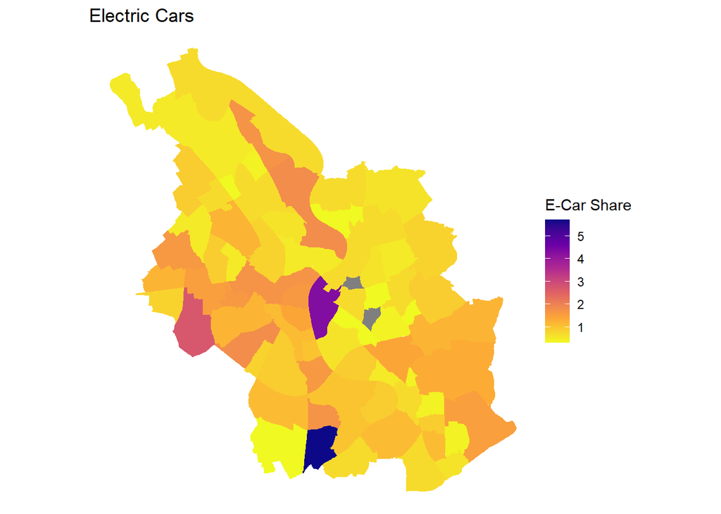

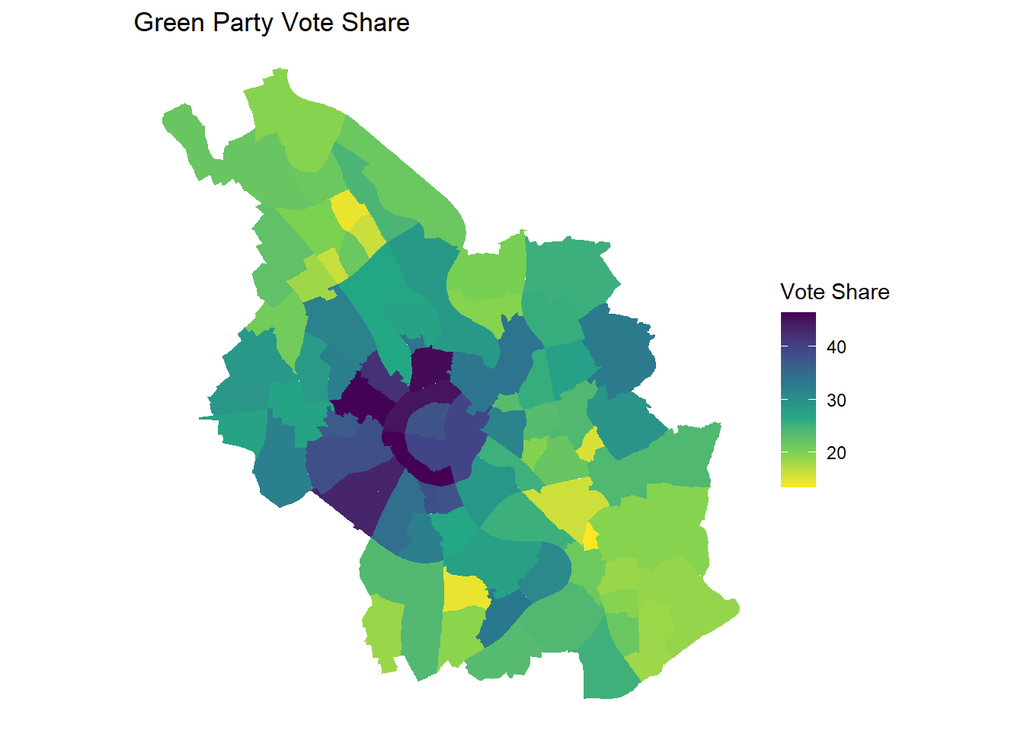

**Tip✅ Solution 2**

```r
charger_cologne <- sf::read_sf("../../data/charger_cologne.shp")

my_map <-
  ggplot() +
  geom_sf(
    data  = attributes_cologne,
    aes(fill = ecar),
    color = NA
  ) +
  scale_fill_viridis_c(
    option    = "magma",
    direction = -1,
    name      = "E-Car Share"
  ) +
  geom_sf(
    data  = charger_cologne,
    # map size to charging power in kW
    aes(size = powr_kw),
    color = "black",
    shape = 17,    # filled triangle — try other numbers!
    alpha = .5
  ) +
  scale_size_continuous(name = "Power (kW)") +
  theme_void() +
  theme(legend.position = "bottom") +
  labs(
    title   = "Electric Cars & Charging Stations in Cologne",
    caption = "© Stadt Köln; Bundesnetzagentur"
  )

my_map

ggsave("my_map.png", my_map, dpi = 300)
```

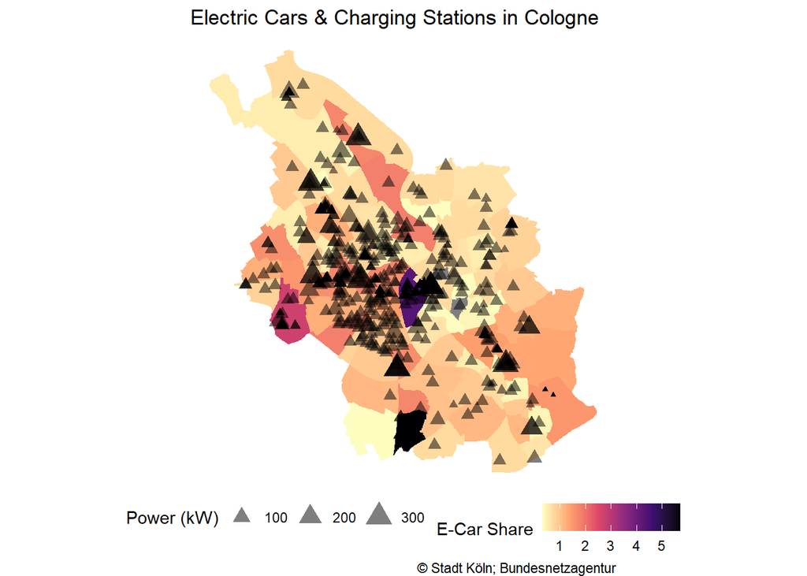

**Tip✅ Solution 3**

```r
# --- Option 1: patchwork ---
library(patchwork)

# combine maps with | (side by side) or / (stacked)
map_ecar | map_greens

# add a shared title
(map_ecar | map_greens) +
  patchwork::plot_annotation(
    title = "Electric Cars and Green Vote Share in Cologne"
  )

# --- Option 2: cowplot ---
library(cowplot)

cowplot::plot_grid(map_ecar, map_greens, ncol = 2, labels = c("A", "B"))

# --- Option 3: facet_wrap ---
library(tidyr)

# pivot two variables to long format first
cologne_long <-
  attributes_cologne |>
  tidyr::pivot_longer(
    cols      = c(cdu, greens),
    names_to  = "variable",
    values_to = "value"
  )

# facet_wrap uses the same color scale for all panels
ggplot() +
  geom_sf(
    data  = cologne_long,
    aes(fill = value),
    color = NA
  ) +
  scale_fill_viridis_c(option = "plasma", direction = -1) +
  facet_wrap(~ variable) +
  theme_void()
```

[output not shown]

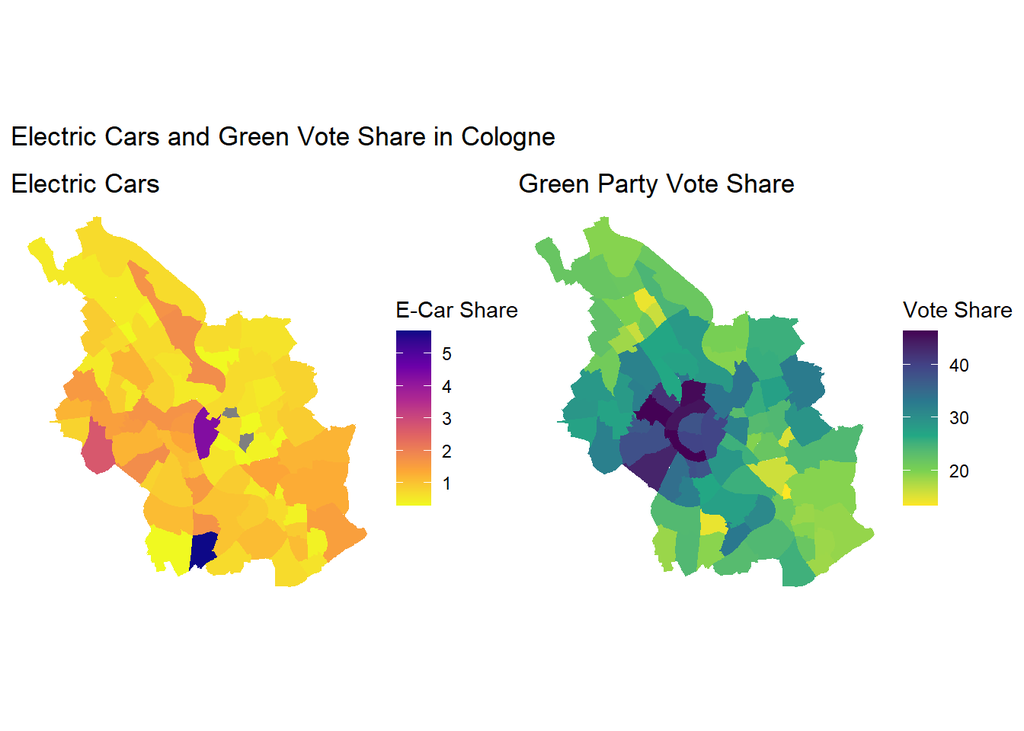